# **Rick and Morty**

## Introduction

> RM fandom is a movie analytics non-profit that analyzes movie data to create visualizations, answer key questions and find interesting patterns in data.

## Aim

> Perform analysis on data from the Rick and Morty API to determine how different features are related to the number of episodes a character appears in.

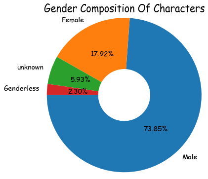

> As seen from the chart above, there are more `Male` characters than anyother gender accounting for over `73%` of the total characters. `Female` characters come a distanct second with about `18%` while `Unknown` and `genderless` round up the ranking.

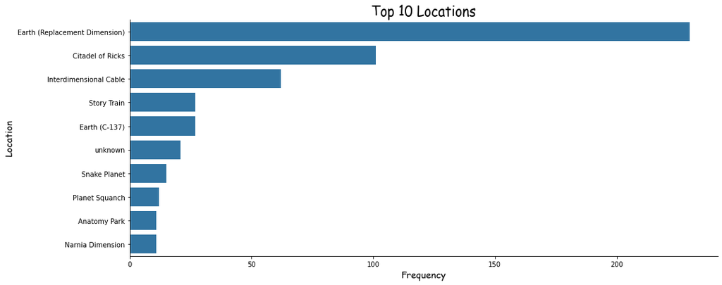

`Earth (replacement Dimension)` is the most popular location with a frequency of `230` with `Citadel of Ricks` and `Interdimensional Cable` wrapping up the top three with `101` and `62` respectively.

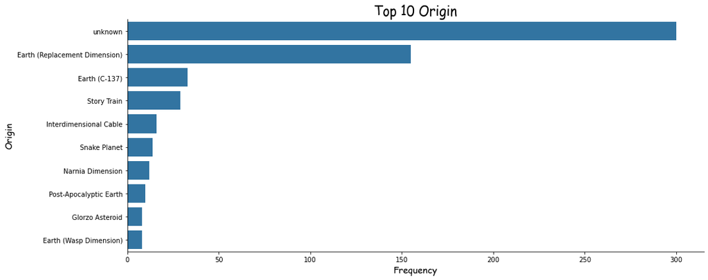

> Majority of characters `(300)` are seen to have an `Unknown` origin which is almost twice the number for second place `Earth (Replacement Dimension)` with `155` and `Earth (C-137)` coming at a distanct third with `33`.

[figure not shown]

> `Rick Sanchez` and `Morty Smith` are the shows most popular with `51 episodes` each. `Summer Smith` and `Beth Smith` rounds the top four with `42 episodes` each.

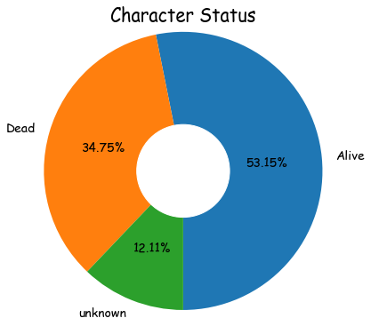

> As seen from the chart above, `53%` of the characters are `alive` with another `34%` `dead` and `12%` have an `unknown` status.

```
No handles with labels found to put in legend.
```

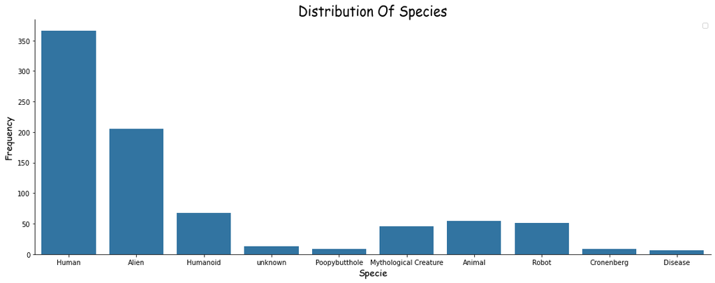

> The chart above shows that the `Human` specie is the most comon appearing over 366 times. This is followed by the `Alien` and `Humanoid` with about 205 and 68 respectively.

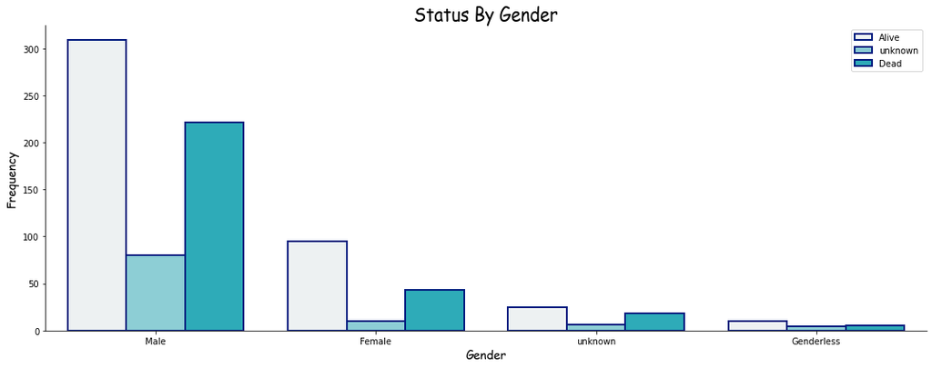

> Looking at the chart above, there are more characyers alive thn dead or unknown. This figure is higher for male characters than any other gender while Dead male characters are also more than that recorded for any other gender.

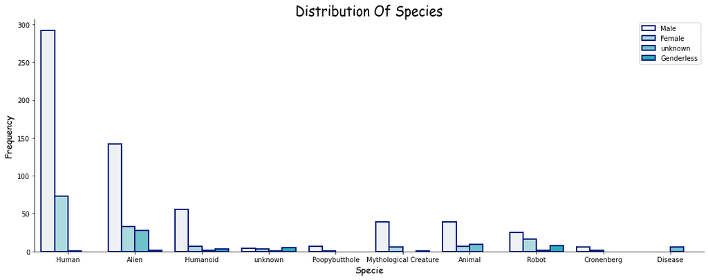

> Male umans are the highest group noted in the data. This is followed by Male Alien and Female Human.

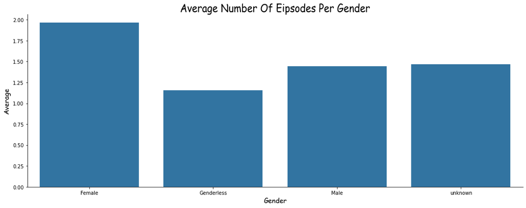

> As noted in the chart above, Female characters have a higher number of episodes than any other gender. This is in contrast to the Genderless character who record the lowest number of episodes on average.

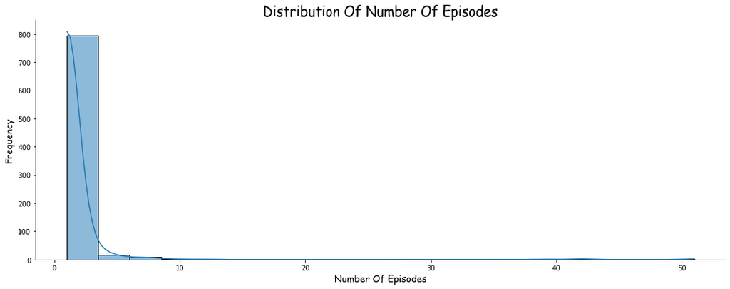

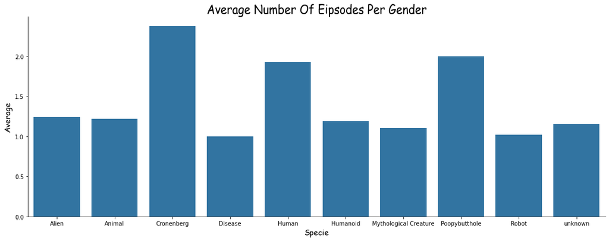

> On average it is noted that `Cronenberg` appear in more episodes than any other specie with an average of 2.4. This is followed by `Poopybutthole` with an average of 2 episodes.

[figure not shown]

While Rick Sanches and Morty Smith are the two most famous characters appearing in 51 episodes each. Generally speaking, the Smith Family appears to be the most famous as seen from the wordcloud above